# HW2_208742890_206661662_207188038

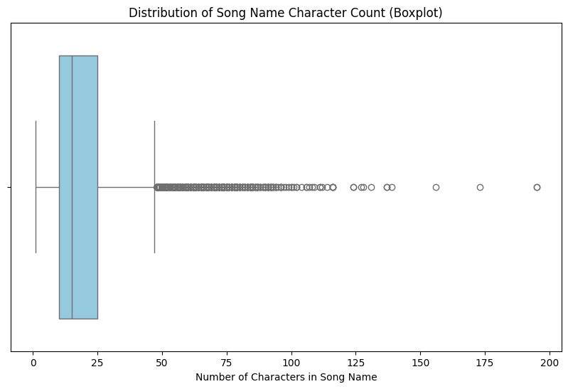

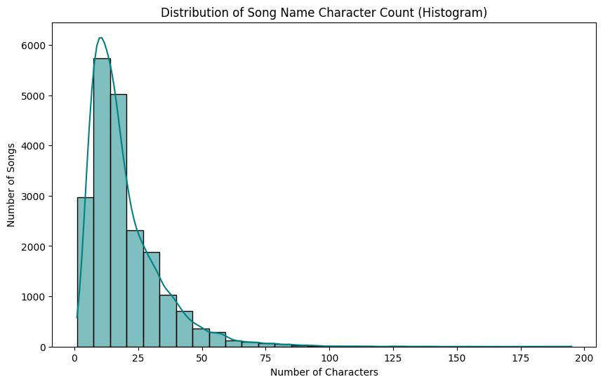

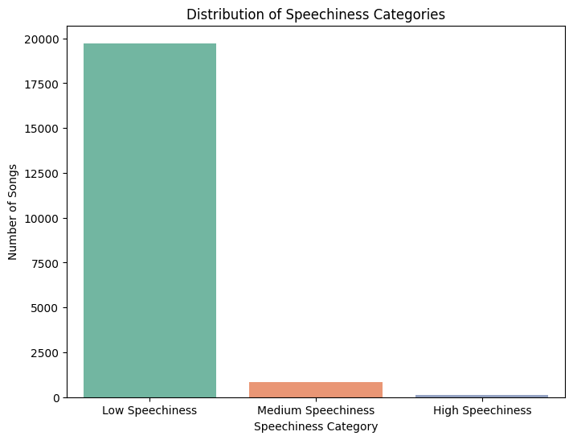

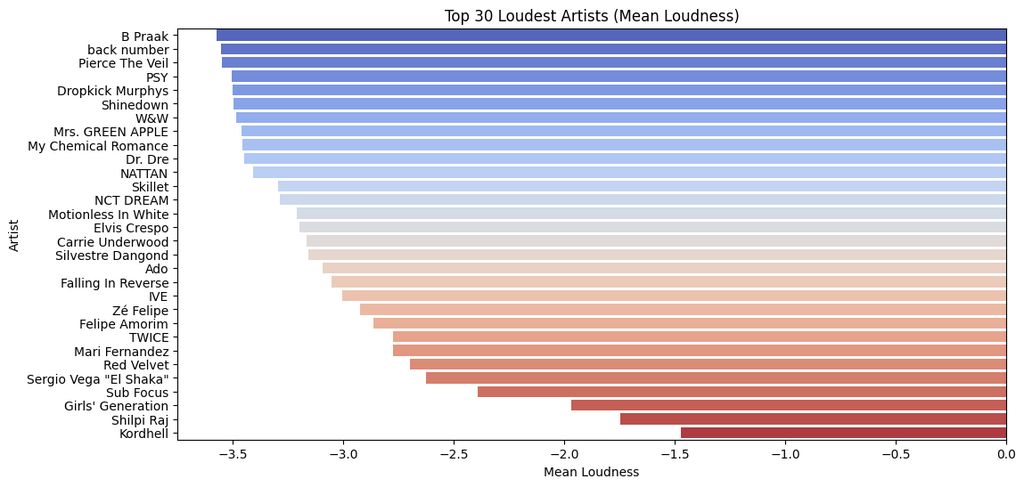

```python
# Song Name Character Count - Boxplot + Histogram
plt.figure(figsize=(10,6))
df['Song_Name_Char_Count'] = df['Track'].str.len()
sns.boxplot(x=df['Song_Name_Char_Count'], color='skyblue')
plt.title('Distribution of Song Name Character Count (Boxplot)')
plt.xlabel('Number of Characters in Song Name')
plt.show()

plt.figure(figsize=(10,6))
sns.histplot(df['Song_Name_Char_Count'], bins=30, kde=True, color='teal')
plt.title('Distribution of Song Name Character Count (Histogram)')
plt.xlabel('Number of Characters')
plt.ylabel('Number of Songs')
plt.show()


# Speechiness Category - Pie Chart
plt.figure(figsize=(8,6))
# צור את Speechiness Category
df['Speechiness_Category'] = pd.cut(
    df['Speechiness'],
    bins=[0, 0.33, 0.66, 1],
    labels=['Low Speechiness', 'Medium Speechiness', 'High Speechiness']
)

sns.countplot(x='Speechiness_Category', data=df, palette='Set2')
plt.title('Distribution of Speechiness Categories')
plt.xlabel('Speechiness Category')
plt.ylabel('Number of Songs')
plt.show()



# Median Loudness per Artist - Boxplot (Top 30)
df['Average_Loudness_Artist'] = df.groupby('Artist')['Loudness'].transform('mean')
top_artists_loud = df.groupby('Artist')['Average_Loudness_Artist'].mean().sort_values().tail(30)
plt.figure(figsize=(12,6))
sns.barplot(x=top_artists_loud.values, y=top_artists_loud.index, palette='coolwarm')
plt.title('Top 30 Loudest Artists (Mean Loudness)')
plt.xlabel('Mean Loudness')
plt.ylabel('Artist')
plt.show()
```

This scatter plot shows the relationship between Energy and Loudness. We can observe if songs with higher energy also tend to have higher loudness. The color by Album_type allows us to see if there's any separation between Singles and Albums.

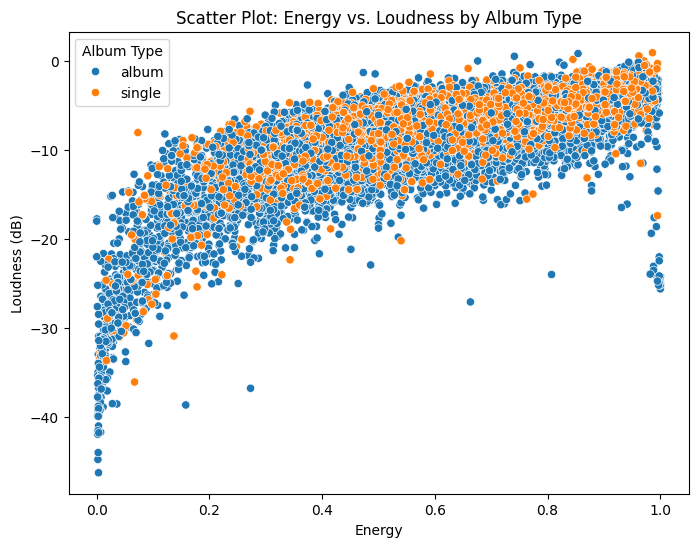

```python
plt.figure(figsize=(8,6))
sns.scatterplot(x='Energy', y='Loudness', hue='Album_type', data=df)
plt.title('Scatter Plot: Energy vs. Loudness by Album Type')
plt.xlabel('Energy')
plt.ylabel('Loudness (dB)')
plt.legend(title='Album Type')
plt.show()
```

This heatmap shows the correlation between different numerical features. High positive correlation (close to 1) means features increase together, while negative correlation (close to -1) indicates opposite trends.

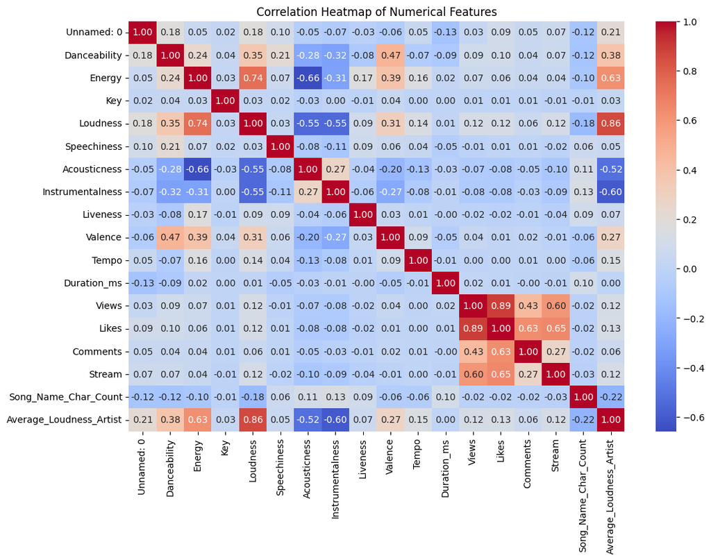

```python
# Select only numeric columns
numeric_df = df.select_dtypes(include=['number'])

# Compute correlation
corr = numeric_df.corr()

# Plot
plt.figure(figsize=(12,8))
sns.heatmap(corr, annot=True, cmap='coolwarm', fmt='.2f')
plt.title('Correlation Heatmap of Numerical Features')
plt.show()
```

The boxplot shows the distribution of views for Singles and Albums. It helps identify differences in popularity and the presence of outliers.

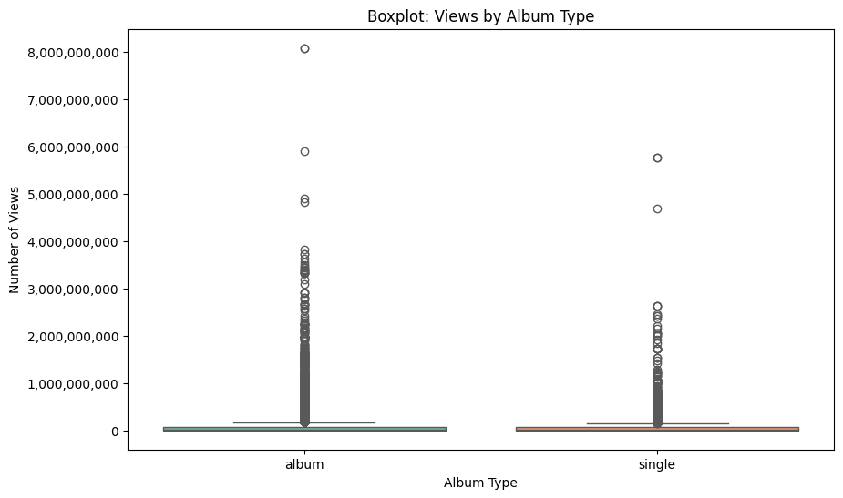

```python
import matplotlib.ticker as mtick

plt.figure(figsize=(10,6))
sns.boxplot(x='Album_type', y='Views', data=df, palette='Set2')
plt.title('Boxplot: Views by Album Type')
plt.xlabel('Album Type')
plt.ylabel('Number of Views')

formatter = mtick.FuncFormatter(lambda x, _: f'{int(x):,}')
plt.gca().yaxis.set_major_formatter(formatter)

plt.show()
```

### Section B - Data Pre-processing

### Your Features

```python
from sklearn.preprocessing import MinMaxScaler

# Combine 'compilation' into 'album'
df['Album_type'] = df['Album_type'].replace('compilation', 'album')

###  Album Song Count ###
# Number of songs in the album
df['Album_Song_Count'] = df.groupby('Album')['Track'].transform('count')

###  Average Artist Song Views ###
# First, check if you have 'Views' column (you might need to adjust this!)
# Since the dataset doesn't seem to have a 'Views' column, let's skip or modify this step
# For now, we'll leave a placeholder (can be adjusted later when views are available)
# df['Average_Artist_Song_Views'] = df.groupby('Artist')['Views'].transform('mean')

###  Song Name Length (Number of Words) ###
df['Song_Name_Length'] = df['Track'].str.split().apply(len)

###  Total Album Length ###
df['Total_Album_Length'] = df.groupby('Album')['Duration_ms'].transform('sum')

###  Fitness for Clubs ###
# Scale Loudness
scaler = MinMaxScaler()
df['Loudness_Scaled'] = scaler.fit_transform(df[['Loudness']])

# Compute Fitness for Clubs
df['Fitness_for_Clubs'] = df[['Danceability', 'Energy', 'Loudness_Scaled', 'Valence']].mean(axis=1)
```

### Our Featuers

> We want to check if the correlation between official_video and licensed is high. If it is we make new feature with the binary values of them, and the views feature.

```python
# We Make numerical Values
df['official_video_score'] = df['official_video'].map({'True': 1.0, 'False': 0.5, True: 1.0, False: 0.5})
df['licensed_score'] = df['Licensed'].map({'True': 1.0, 'False': 0.5, True: 1.0, False: 0.5})

# Correlation calculation
correlation = df[['official_video_score', 'licensed_score']].corr().iloc[0, 1]
print(f" Correlation between 'official_video' and 'Licensed': {correlation:.3f}")

# Featue making be correlation
if abs(correlation) >= 0.7:
    df['official_licensed_views'] = (
        df['official_video_score'] * df['licensed_score'] * df['Views']
    )
    print(" New Feature came to be: official_licensed_views")
else:
    print("The correlation is not high enough to make a new feature ")

# Show results
print(df[['official_video', 'Licensed', 'Views', 'official_licensed_views']].head())
```

```
 Correlation between 'official_video' and 'Licensed': 0.816
 New Feature came to be: official_licensed_views
  official_video Licensed        Views  official_licensed_views
0           True     True  693555221.0              693555221.0
1           True     True   72011645.0               72011645.0
2           True     True    8435055.0                8435055.0
3           True     True  211754952.0              211754952.0
4           True     True  618480958.0              618480958.0
```

> Song Character count

```python
### Song Name Character Count ###
df['Song_Name_Char_Count'] = df['Track'].str.len()
```

> Artist Song Count

```python
### Artist Song Count ###
df['Artist_Song_Count'] = df.groupby('Artist')['Track'].transform('count')
```

> Compute Engagement Rate

```python
# Compute Engagement Rate
df['Engagement_Rate'] = (df['Likes'] + df['Comments']) / (df['Views'] + 1)  # +1 to avoid division by zero
```

> Sum up Views + Likes + Streams

```python
# Sum up Views + Likes + Streams
df['Raw_Release_Popularity'] = df['Views'] + df['Likes'] + df['Stream']
```

> Average of Valence and Energy. It can be done cause both are in the range of (0,1)

```python
df['valence_energy_avg'] = (df['Valence'] + df['Energy']) / 2
```

> Songs that share the same name as their album are often lead singles or title tracks. They may carry unique characteristics in terms of popularity, importance within the album, or stylistic emphasis.

```python
df['track_equals_album'] = (df['Track'].str.lower().str.strip() == df['Album'].str.lower().str.strip()).astype(int)
```

> Showing all the features as list

```python
print(df.columns.tolist())
```

```
['Unnamed: 0', 'Artist', 'Url_spotify', 'Track', 'Album', 'Album_type', 'Uri', 'Danceability', 'Energy', 'Key', 'Loudness', 'Speechiness', 'Acousticness', 'Instrumentalness', 'Liveness', 'Valence', 'Tempo', 'Duration_ms', 'Url_youtube', 'Title', 'Channel', 'Views', 'Likes', 'Comments', 'Description'…
```

### Imputation

```python
# Group-Based Imputation for numerical columns
group_cols = ['Views', 'Likes', 'Comments', 'Stream']
for col in group_cols:
    if col in df.columns:
        df[col] = df.groupby('Artist')[col].transform(lambda x: x.fillna(x.mean()))

# General Imputation for remaining numerical columns (excluding target)
num_cols = df.select_dtypes(include=['float64', 'int64']).columns.tolist()
num_cols = [col for col in num_cols if col not in group_cols + ['Is_Single']]

for col in num_cols:
    df[col] = df[col].fillna(df[col].mean())

# Replace inf with NaN, then fill (numerical columns only)
df[num_cols + group_cols] = df[num_cols + group_cols].replace([np.inf, -np.inf], np.nan)
df[num_cols + group_cols] = df[num_cols + group_cols].fillna(0)

# Check missing values after numeric imputation
print("\nMissing values after numeric imputation:\n", df[num_cols + group_cols].isnull().sum())
```

```
Missing values after numeric imputation:
 Unnamed: 0                 0
Danceability               0
Energy                     0
Key                        0
Loudness                   0
Speechiness                0
Acousticness               0
Instrumentalness           0
Liveness                   0
Valence                    0
Tempo                      0
Duration_ms                0
Song_Name_Char_Count       0
Average_Loudness_Artist    0
Album_Song_Count           0
Song_Name_Length           0
Total_Album_Length         0
Loudness_Scaled            0
Fitness_for_Clubs          0
official_video_score       0
licensed_score             0
official_licensed_views    0
Artist_Song_Count          0
Engagement_Rate            0
Raw_Release_Popularity     0
valence_energy_avg         0
track_equals_album         0
Views                      0
Likes                      0
Comments                   0
Stream                     0
dtype: int64
```

### Exclusion

We got rid from the features that are text based, and has no use for the classifing, or the clustering, because they are not helpful for clustering, where is needed numerical attributes, and has no particular use in classifing. And from the unNamed because it is only a numrator

```python
#Feature Selection
df = df.drop(columns=['Unnamed: 0', 'Url_spotify', 'Uri', 'Url_youtube', 'Title','Channel', 'Description'])
```

```python
df.info()
```

```
<class 'pandas.core.frame.DataFrame'>
RangeIndex: 20718 entries, 0 to 20717
Data columns (total 37 columns):
 #   Column                   Non-Null Count  Dtype
---  ------                   --------------  -----
 0   Artist                   20718 non-null  object
 1   Track                    20718 non-null  object
 2   Album                    20718 non-null  object
 3   Album_type               20718 non-null  object
 4   Danceability             20718 non-null  float64
 5   Energy                   20718 non-null  float64
 6   Key                      20718 non-null  float64
 7   Loudness                 20718 non-null  float64
 8   Speechiness              20718 non-null  float64
 9   Acousticness             20718 non-null  float64
```

[output cut: 29 more lines]